# methylKit: User Guide v0.99.4

# 4 Annotating differentially methylated bases or regions

We can annotate our differentially methylated regions/bases based on gene annotation using [genomation](https://bioconductor.org/packages/release/bioc/html/genomation.html) package. In this example, we read the gene annotation from a BED file and annotate our differentially methylated regions with that information using genomation functions. Note that these functions operate on `GRanges` objects ,so we first coerce methylKit objects to GRanges. This annotation operation will tell us what percentage of our differentially methylated regions are on promoters/introns/exons/intergenic region. In this case we read annotation from a BED file, similar gene annotation information can be fetched using `GenomicFeatures` package or other packages available from Bioconductor.org.

```r
library(genomation)
# read the gene BED file
gene.obj=readTranscriptFeatures(system.file("extdata", "refseq.hg18.bed.txt",
                                           package = "methylKit"))
```

```
## Reading the table...
```

```
## Calculating intron coordinates...
```

```
## Calculating exon coordinates...
```

```
## Calculating TSS coordinates...
```

```
## Calculating promoter coordinates...
```

```
## Outputting the final GRangesList...
```

```r
#
# annotate differentially methylated CpGs with
# promoter/exon/intron using annotation data
#
annotateWithGeneParts(as(myDiff25p,"GRanges"),gene.obj)
```

```
## Summary of target set annotation with genic parts
```

```
## Rows in target set: 133
```

```
## percentage of target features overlapping with annotation:
```

```
##   promoter       exon     intron intergenic
##      27.82      15.04      34.59      57.14
```

```
##
## percentage of target features overlapping with annotation:
```

```
## (with promoter > exon > intron precedence):
```

```
##   promoter       exon     intron intergenic
##      27.82       0.00      15.04      57.14
```

```
## percentage of annotation boundaries with feature overlap:
```

```
## promoter     exon   intron
##     0.29     0.03     0.17
```

```
## summary of distances to the nearest TSS:
```

```
##    Min. 1st Qu.  Median    Mean 3rd Qu.    Max.
##       5     828   45160   52030   94640  313500
```

Similarly, we can read the CpG island annotation and annotate our differentially methylated bases/regions with them.

```r
# read the shores and flanking regions and name the flanks as shores
# and CpG islands as CpGi
cpg.obj=readFeatureFlank(system.file("extdata", "cpgi.hg18.bed.txt",
                                        package = "methylKit"),
                           feature.flank.name=c("CpGi","shores"))
#
# convert methylDiff object to GRanges and annotate
diffCpGann=annotateWithFeatureFlank(as(myDiff25p,"GRanges"),
                                    cpg.obj$CpGi,cpg.obj$shores,
                         feature.name="CpGi",flank.name="shores")
```

## 4.1 Regional analysis

We can also summarize methylation information over a set of defined regions such as promoters or CpG islands. The function below summarizes the methylation information over a given set of promoter regions and outputs a `methylRaw` or `methylRawList` object depending on the input. We are using the output of genomation functions used above to provide the locations of promoters. For regional summary functions, we need to provide regions of interest as GRanges object.

```r
promoters=regionCounts(myobj,gene.obj$promoters)

head(promoters[[1]])
```

```
## methylRaw object with 6 rows
## --------------
##     chr    start      end strand coverage numCs numTs
## 1 chr21 10011791 10013791      -     7953  6662  1290
## 2 chr21 10119796 10121796      -     1725  1171   554
## 3 chr21 10119808 10121808      -     1725  1171   554
## 4 chr21 13903368 13905368      +       10    10     0
## 5 chr21 14273636 14275636      -      282   220    62
## 6 chr21 14509336 14511336      +     1058    55  1003
## --------------
## sample.id: test1
## assembly: hg18
## context: CpG
## resolution: region
```

## 4.2 Convenience functions for annotation objects

After getting the annotation of differentially methylated regions, we can get the distance to TSS and nearest gene name using the `getAssociationWithTSS` function from genomation package.

```r
diffAnn=annotateWithGeneParts(as(myDiff25p,"GRanges"),gene.obj)

# target.row is the row number in myDiff25p
head(getAssociationWithTSS(diffAnn))
```

```
##      target.row dist.to.feature feature.name feature.strand
## 60            1          106111    NM_199260              -
## 60.1          2          106098    NM_199260              -
## 60.2          3          106092    NM_199260              -
## 60.3          4          105919    NM_199260              -
## 60.4          5           85265    NM_199260              -
## 60.5          6           68287    NM_199260              -
```

It is also desirable to get percentage/number of differentially methylated regions that overlap with intron/exon/promoters

```r
getTargetAnnotationStats(diffAnn,percentage=TRUE,precedence=TRUE)
```

```
##   promoter       exon     intron intergenic
##      27.82       0.00      15.04      57.14
```

We can also plot the percentage of differentially methylated bases overlapping with exon/intron/promoters

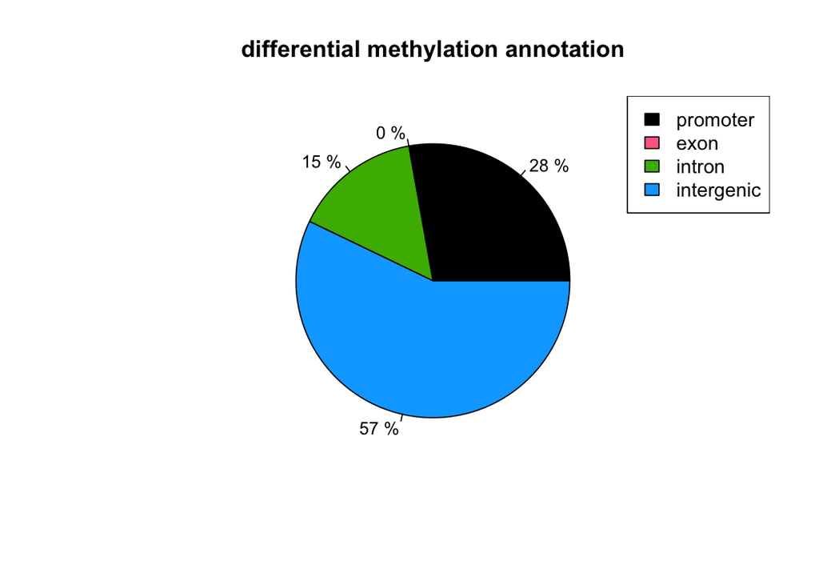

```r
plotTargetAnnotation(diffAnn,precedence=TRUE,
    main="differential methylation annotation")
```

We can also plot the CpG island annotation the same way. The plot below shows what percentage of differentially methylated bases are on CpG islands, CpG island shores and other regions.

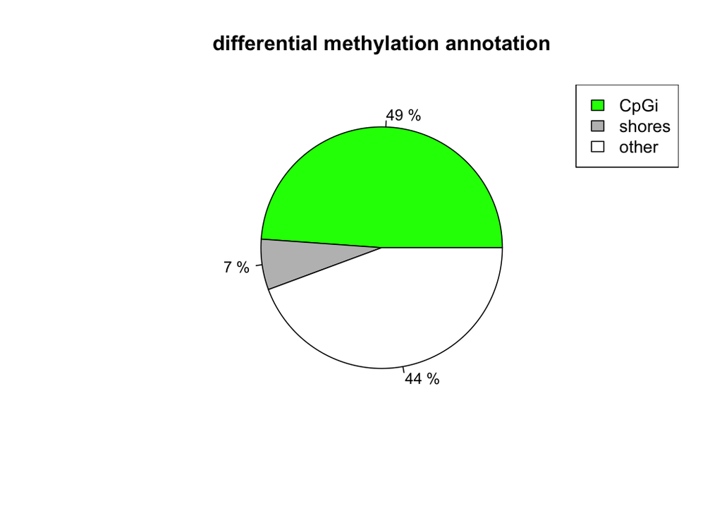

```r
plotTargetAnnotation(diffCpGann,col=c("green","gray","white"),
       main="differential methylation annotation")
```

It might be also useful to get percentage of intron/exon/promoters that overlap with differentially methylated bases.

```r
getFeatsWithTargetsStats(diffAnn,percentage=TRUE)
```

```
## promoter     exon   intron
##     0.29     0.03     0.17
```

# 5 methylKit convenience functions

## 5.1 Coercing methylKit objects to GRanges

Most `methylKit` objects (methylRaw,methylBase and methylDiff), including methylDB objects (methylRawDB,methylBaseDB and methylDiffDB) can be coerced to `GRanges` objects from `GenomicRanges` package. Coercing methylKit objects to `GRanges` will give users additional flexibility when customizing their analyses.

```r
class(meth)
```

```
## [1] "methylBase"
## attr(,"package")
## [1] "methylKit"
```

```r
as(meth,"GRanges")
```

```
## GRanges object with 963 ranges and 12 metadata columns:
##         seqnames               ranges strand | coverage1    numCs1
##            <Rle>            <IRanges>  <Rle> | <integer> <numeric>
##     [1]    chr21   [9853296, 9853296]      + |        17        10
##     [2]    chr21   [9853326, 9853326]      + |        17        12
##     [3]    chr21   [9860126, 9860126]      + |        39        38
##     [4]    chr21   [9906604, 9906604]      + |        68        42
##     [5]    chr21   [9906616, 9906616]      + |        68        52
##     ...      ...                  ...    ... .       ...       ...
##   [959]    chr21 [19855690, 19855690]      + |        27        26
##   [960]    chr21 [19855706, 19855706]      + |        27        27
##   [961]    chr21 [19855711, 19855711]      + |        18        18
##   [962]    chr21 [19943653, 19943653]      + |        12        12
##   [963]    chr21 [19943695, 19943695]      + |        12        11
##            numTs1 coverage2    numCs2    numTs2 coverage3    numCs3
```

[output cut: 27 more lines]

```r
class(myDiff)
```

```
## [1] "methylDiff"
## attr(,"package")
## [1] "methylKit"
```

```r
as(myDiff,"GRanges")
```

```
## GRanges object with 963 ranges and 2 metadata columns:
##         seqnames               ranges strand |              qvalue
##            <Rle>            <IRanges>  <Rle> |           <numeric>
##     [1]    chr21   [9853296, 9853296]      + |  0.0215658126063665
##     [2]    chr21   [9853326, 9853326]      + |   0.592173028310101
##     [3]    chr21   [9860126, 9860126]      + |  0.0697808391745448
##     [4]    chr21   [9906604, 9906604]      + |   0.259453089661393
##     [5]    chr21   [9906616, 9906616]      + | 0.00432220069940914
##     ...      ...                  ...    ... .                 ...
##   [959]    chr21 [19855690, 19855690]      + |  0.0660274910679261
##   [960]    chr21 [19855706, 19855706]      + |   0.282958728725395
##   [961]    chr21 [19855711, 19855711]      + |  0.0446545923565475
##   [962]    chr21 [19943653, 19943653]      + |   0.592173028310101
##   [963]    chr21 [19943695, 19943695]      + |   0.396045532748492
##                 meth.diff
##                 <numeric>
##     [1] -7.01210653753027
##     [2] 0.209135938359928
##     [3] -4.11158117398203
##     [4] -7.34636871508379
##     [5]  18.8175046554935
##     ...               ...
##   [959] -6.52173913043478
##   [960]  2.17391304347826
##   [961] -8.33333333333334
##   [962]  1.45454545454546
##   [963]  3.38765008576329
##   -------
##   seqinfo: 1 sequence from an unspecified genome; no seqlengths
```

## 5.2 Converting methylKit objects to methylDB objects and vice versa

**methylDB** objects (`methylRawDB`, `methylBaseDB` and `methylDiffDB`) can be coerced to normal `methylKit` objects. This might speed up the analysis if sufficient computing resources are available. This can be done via “as()” function.

```r
class(myobjDB[[1]])
```

```
## [1] "methylRawDB"
## attr(,"package")
## [1] "methylKit"
```

```r
as(myobjDB[[1]],"methylRaw")
```

```
## methylRaw object with 1904 rows
## --------------
##     chr   start     end strand coverage numCs numTs
## 1 chr21 9764513 9764513      -       12     0    12
## 2 chr21 9764539 9764539      -       12     3     9
## 3 chr21 9820622 9820622      +       13     0    13
## 4 chr21 9837545 9837545      +       11     0    11
## 5 chr21 9849022 9849022      +      124    90    34
## 6 chr21 9853296 9853296      +       17    10     7
## --------------
## sample.id: test1
## assembly: hg18
## context: CpG
## resolution: base
```

```r
data(methylKit)

objDB=makeMethylDB(methylBase.obj,"exMethylDB")
```